# Simulation Exercise Report

Borye, 25/10/2014

Friday, November 07, 2014

### Introduction

This is a project for the statistical inference class hold by coursera. In this part of the project, I will use simulation to explore inference and do some simple inferential data analysis.

The exponential distribution can be simulated in R with rexp(n, lambda) where lambda is the rate parameter. The mean of exponential distribution is 1/lambda and the standard deviation is also also 1/lambda. **Set lambda = 0.2** for all of the simulations. In this simulation, you will investigate the distribution of averages of 40 exponential(0.2)s. I will need to do a thousand or so simulated averages of 40 exponentials.

### Question 1, Show where the distribution is centered at and compare it to the theoretical center of the distribution

First, I plot the original distribution of the rexp(40, 0.2)

```
## stat_bin: binwidth defaulted to range/30. Use 'binwidth = x' to adjust this.
```

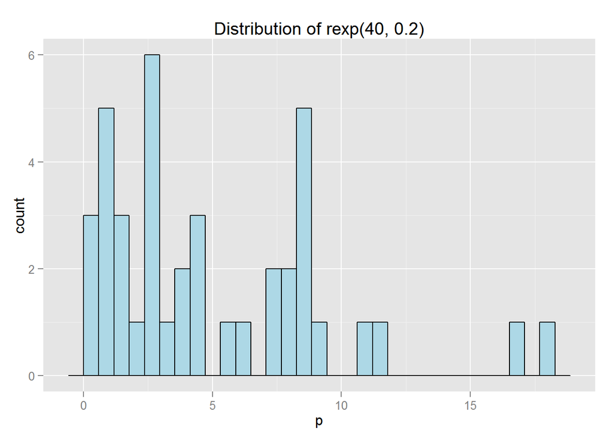

```r
library(ggplot2)
p <- rexp(40, 0.2)
g = ggplot(data.frame(p = p), aes(x = p))
g = g + geom_histogram(color = "black", fill = "lightblue") + labs(title = "Distribution of rexp(40, 0.2)")
g
```

```
## stat_bin: binwidth defaulted to range/30. Use 'binwidth = x' to adjust this.
```

[figure not shown]

```r
mns = NULL
for (i in 1 : 100) mns = c(mns, mean(rexp(40, 0.2)))
vlines <- data.frame(xint = c(5, mean(mns)), grp = c("a", "b"))
g = ggplot(data.frame(mns), aes(x = mns))
g = g + geom_histogram(color = "black", fill = "lightblue") + geom_vline(data = vlines, aes(xintercept = xint, colour = grp), size = 1.5) + labs(title = "Distribution of 1000 averages of 40 random rexp(40, 0.2)")
g
```

We could seen from this plot that the **red line shows the theoretical center of the distribution which is 5 (1/0.2)**. While the **blue line shows the center of the distribution**. We can seen from this plot that these two lines are very close to each other. The actual mean of the distributio is shown below.

```r
mean(mns)
```

```
## [1] 5.033974
```

### Question 2, show how variable it is and compare it to the theoretical variance of the distribution

```r
var(mns)
```

```
## [1] 0.6418998
```

The theoretical variance of the distribution should be **(1/lambda)^2/n** which shownd as below

```r
(1/0.2)^2/40
```

```
## [1] 0.625
```